# Final_All_Code_Student_Performance

Group L02G06

Niharika Chomal, Yutong Han, Zichun Han, Yizhen Pan and Hannah Pwint Shwe Yi Oo

Disclaimer:  
- Dataset description/ EDA investigation code is written by Hannah Pwint Shwe Yi Oo  
- Model Selection Code is written by Yizhen Pan.  
- Assumption Code is written by Zichun Han.

NOTE: Data Used in this file should be in a folder called ‘student’ (the student.zip file given to us) in the same level directory as this file.

```r
# Load necessary libraries
library(dplyr)
library(broom)
library(MASS)
library(car)
library(lmtest)
library(ggplot2)
library(tidyverse)
library(visdat)
library(patchwork)
theme_set(theme_bw())
library(tidyr)
```

# Data Description

Dataset description/ EDA investigation code is written by Hannah Pwint Shwe Yi Oo

Our data is Student Performance from UC Irvine Machine Learning Repository. We have 2 data sets but both have same 30 features with different entry values. The data is from two Portuguese secondary education schools collecting data via school reports and questionnaires.

Data source URL: https://archive.ics.uci.edu/dataset/320/student+performance

Each data set has G3 column which is the final grade we want to predict. One data set is Math final grade related and the other is Portuguese final grade related. There are no missing values in both data sets and there is strong correlation between G3, G1, and G2 because G1 and G2 are grades from period 1 and 2.

There are more rows in Portuguese data set than Math data set. Math Data is 395 x 33 dimension and Portuguese Data is 649 x 33.

```r
# Load data
og.d1=read.table("student/student-mat.csv",sep=";",header=TRUE) # d1 is Math
og.d2=read.table("student/student-por.csv",sep=";",header=TRUE) # d2 is Portuguese

d1 <- og.d1 %>% filter(G3 != 0) # filter to select rows where G3 is not zero
d2 <- og.d2 %>% filter(G3 != 0) # filter to select rows where G3 is not zero
d2 <- og.d2 %>% filter(G3 != 1) # filter to select rows where G3 is not zero

log.d1 <- d1
log.d1$G3 <- log(d1$G3)
log.d2 <- d2
log.d2$G3 <- log(d2$G3)
```

#### Code for EDA of G3 for the report

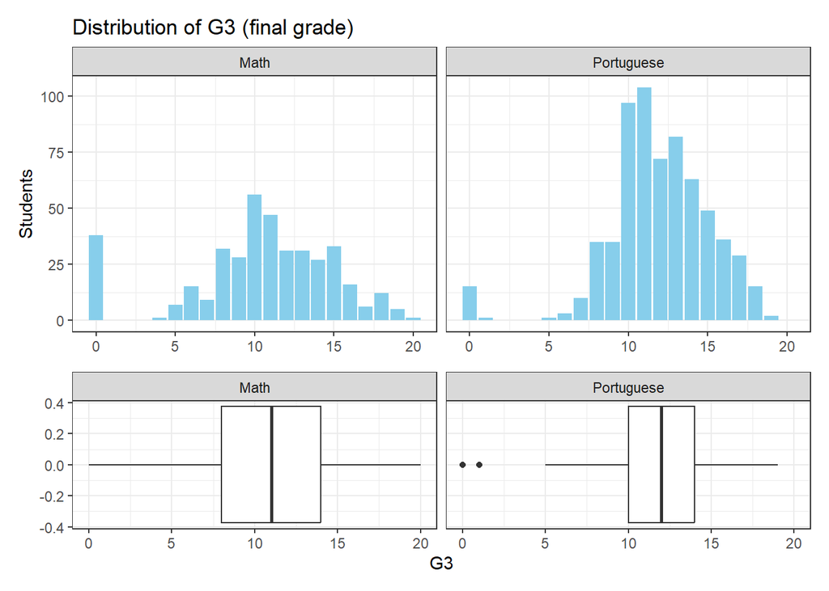

```r
dataset_table <- data.frame(
  Variable_Names = c("sex, schoolsup, famsup, paid, activities, nursery, higher, internet, romantic", "school, address, famsize, Pstatus, Mjob, Fjob, reason, guardian", "Medu, Fedu, traveltime, studytime, failures", "famrel, freetime, goout, Dalc, Walc, health","age, absences, G1, G2, G3"),
  Type = c("Binary", "Nominal Category", "Ordinal Category", "Likert Scale", "Discrete Numerical"),
  Class = c("Boolean", "Character", "Integer", "Integer", "Integer")
)

my.og.d1 <- og.d1
my.og.d2 <- og.d2
my.og.d1$Subject = "Math"
my.og.d2$Subject = "Portuguese"

my.og.d1 <- my.og.d1 %>% dplyr::select(Subject, G3)
my.og.d2 <- my.og.d2 %>% dplyr::select(Subject, G3)

combined <- rbind(my.og.d1, my.og.d2)

boxplot <- combined |> ggplot() + aes(x = G3) +
  geom_boxplot() +
  facet_grid( . ~ Subject) +
  labs(x = "G3")

barplot <- combined |> ggplot() +
   geom_bar(aes(x = G3), fill = "skyblue") +
   facet_grid( . ~ Subject) +
  labs(y = "Students", x = NULL, title = "Distribution of G3 (final grade)")


barplot / boxplot + plot_layout(heights = c(2, 1))
```

##### Check Missing Data (This graph is not important)

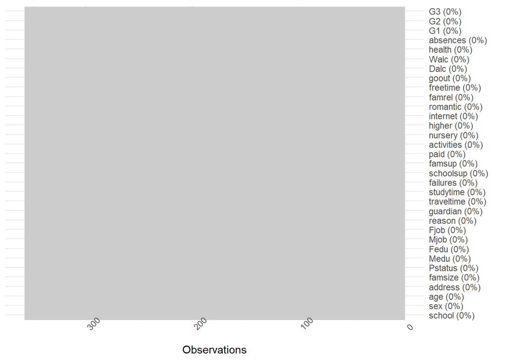

```r
visdat::vis_miss(d1) + coord_flip() + theme(legend.position = "none")
```

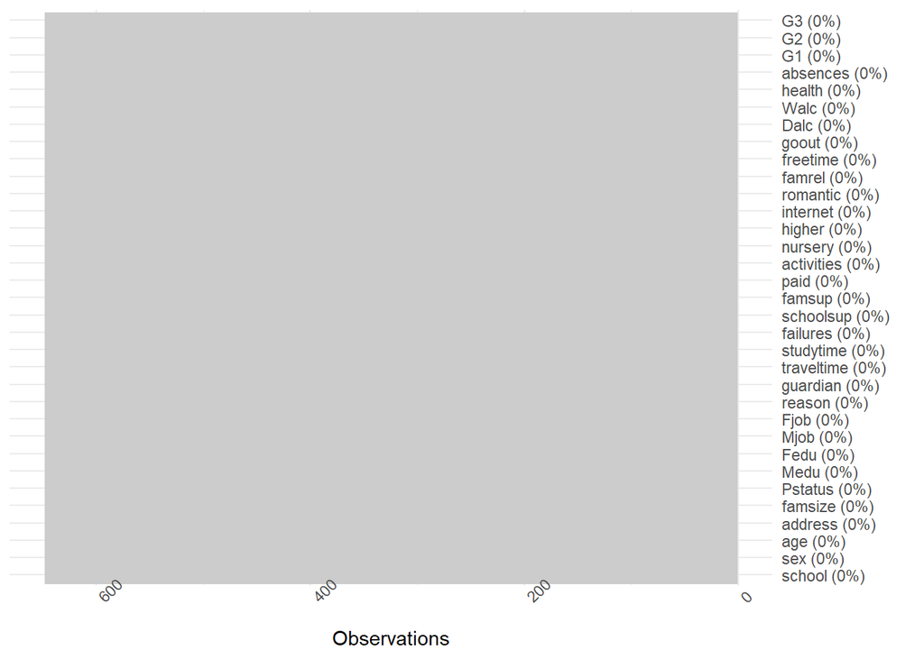

```r
visdat::vis_miss(d2) + coord_flip() + theme(legend.position = "none")
```

Both data sets show that there are no missing values.

##### Check Variable Distribution For Numerical Data

Math Data Set

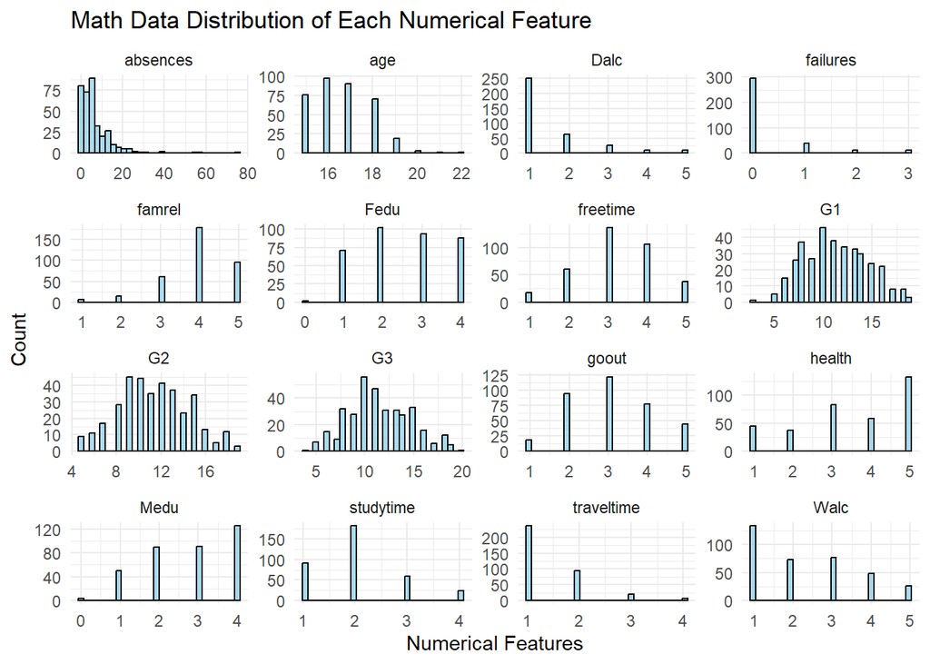

```r
d1 %>%
  pivot_longer(cols = where(is.numeric)) %>%
  ggplot(aes(x = value)) +
  geom_histogram(bins = 30, fill = "skyblue", color = "black", alpha = 0.7) +
  facet_wrap(~name, scales = "free") +
  theme_minimal() +
  labs(x = "Numerical Features", y = "Count", title = "Math Data Distribution of Each Numerical Feature")
```

Portuguese Dataset

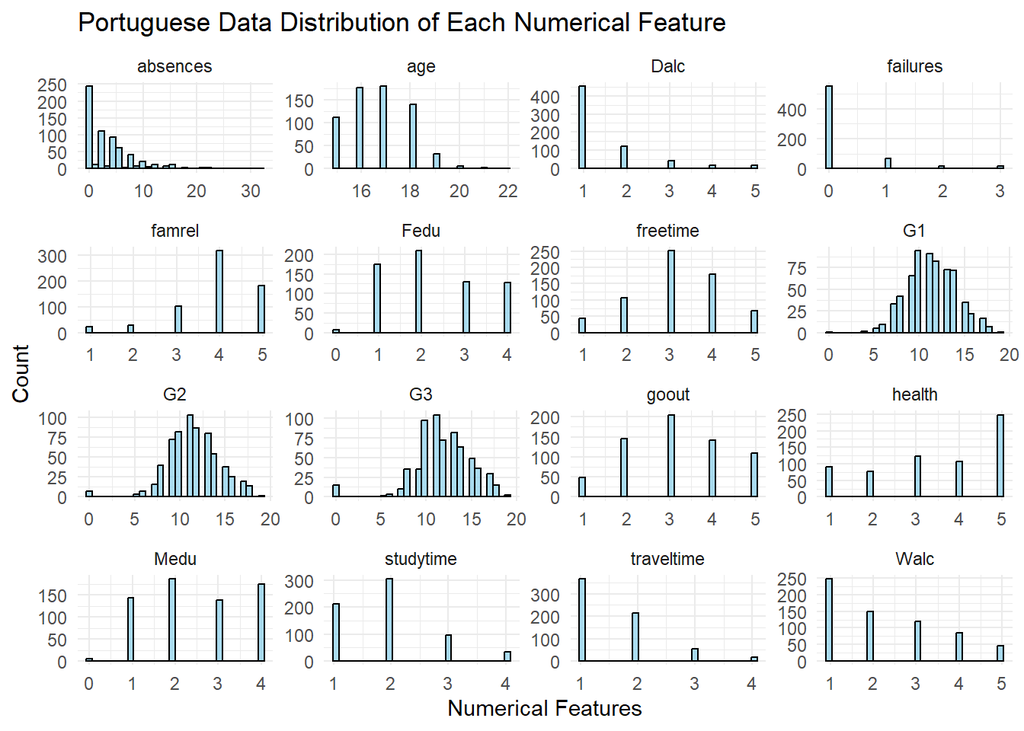

```r
d2 %>%
  pivot_longer(cols = where(is.numeric)) %>%
  ggplot(aes(x = value)) +
  geom_histogram(bins = 30, fill = "skyblue", color = "black", alpha = 0.7) +
  facet_wrap(~name, scales = "free") +
  theme_minimal() +
  labs(x = "Numerical Features", y = "Count", title = "Portuguese Data Distribution of Each Numerical Feature")
```

Both Math and Portuguese Data sets are similarly distributed.

##### Check Variable Relationship With G3 and transformed datasets

log(Math) numerical

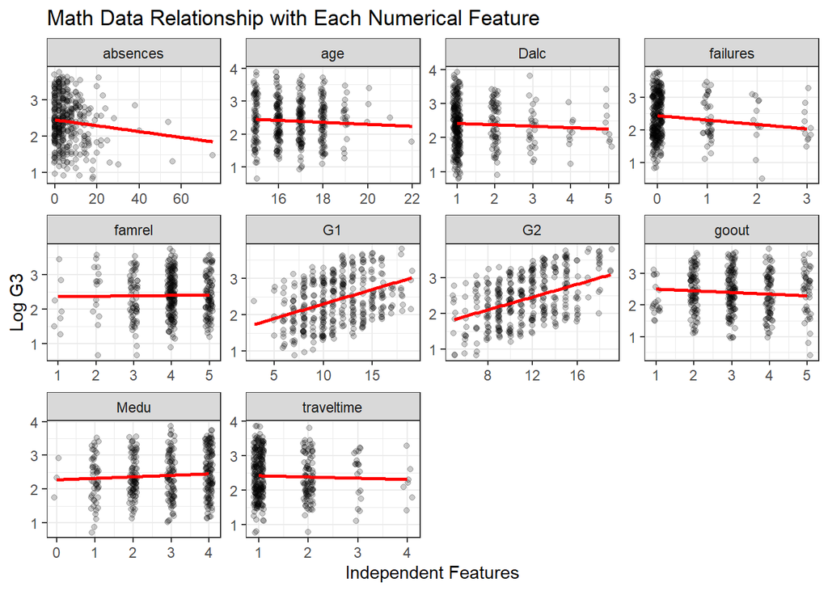

```r
log.d1 %>%
  dplyr::select(G2, famrel, absences, Medu, goout, G1, failures, age, Dalc, traveltime, G3) %>%
  pivot_longer(-G3) %>%
  ggplot(aes(x=value,y=G3))  +
  geom_jitter(width=0.1,height=1,alpha=0.2)+
  geom_smooth(method= "lm", color = "red", se = FALSE)+
  facet_wrap(~name,scales='free') +
  labs(x = "Independent Features", y = "Log G3", title = "Math Data Relationship with Each Numerical Feature")
```

For Math data set, we can see strong correlation between G1 and G3 and G2 and G3. There is also slight correlation between failures, age, Dalc, goout, Medu vs G3.

log(Portuguese) numerical

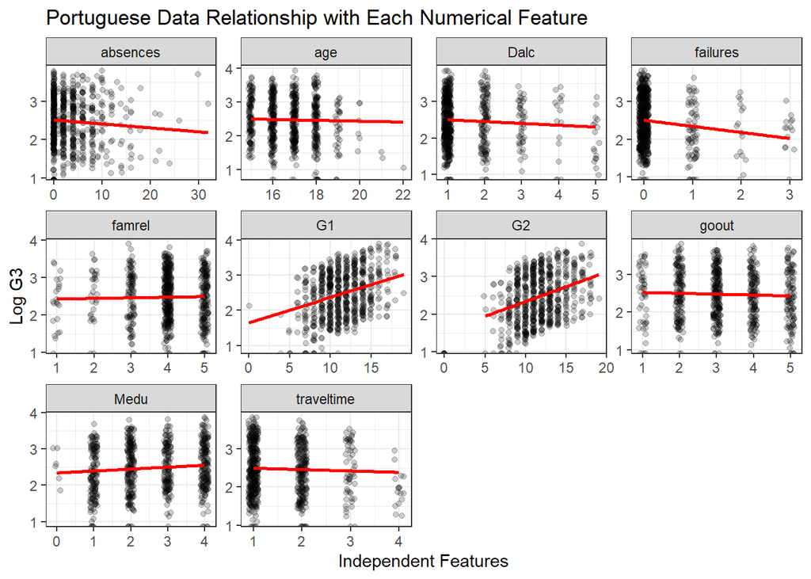

```r
log.d2 %>%
  dplyr::select(G2, famrel, absences, Medu, goout, G1, failures, age, Dalc, traveltime, G3) %>%
  pivot_longer(-G3) %>%
  ggplot(aes(x=value,y=G3))  +
  geom_jitter(width=0.1,height=1,alpha=0.2)+
  geom_smooth(method= "lm", color = "red", se = FALSE)+
  facet_wrap(~name,scales='free') +
  labs(x = "Independent Features", y = "Log G3", title = "Portuguese Data Relationship with Each Numerical Feature")
```

log(Math) categorical

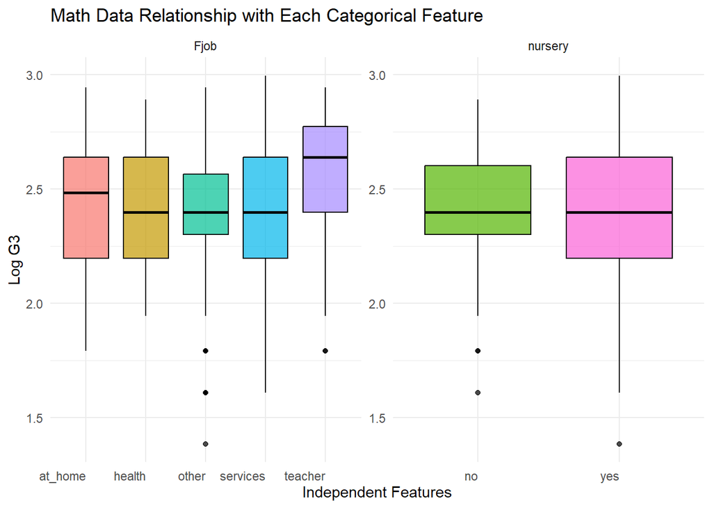

```r
log.d1 %>% dplyr::select(nursery, Fjob, G3) %>% pivot_longer(-G3) %>%
  ggplot(aes(x = value, y = G3, fill = value)) +
  geom_boxplot(color = "black", alpha = 0.7) +
  facet_wrap(~name, scales = 'free') +
  labs(x = "Independent Features", y = "Log G3", title = "Math Data Relationship with Each Categorical Feature") +
  theme_minimal() +
  theme(axis.text.x = element_text(vjust = 0.5, hjust = 1)) +guides(fill = "none")
```

log(Portuguese) categorical

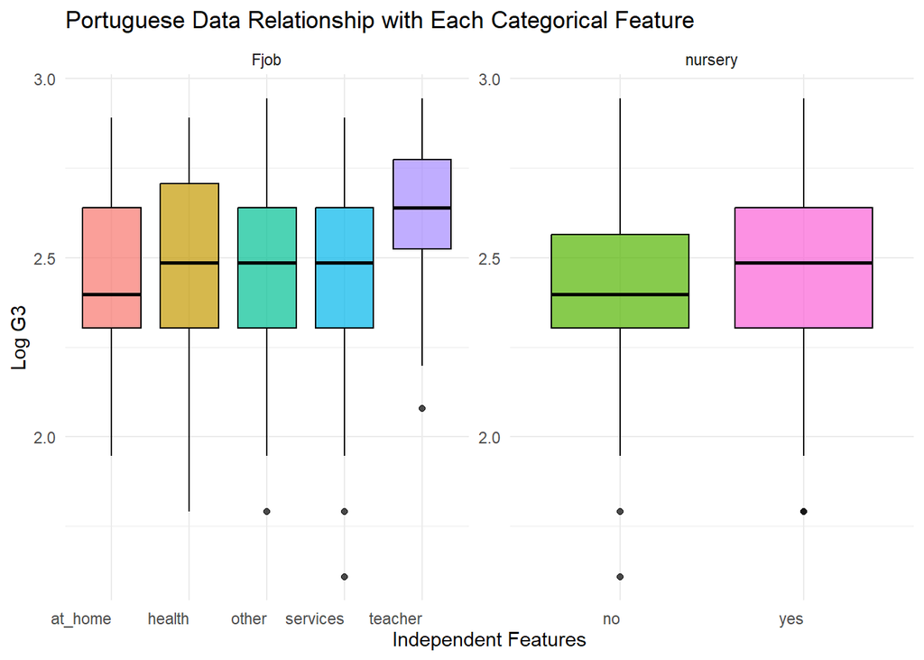

```r
log.d2 %>% dplyr::select(nursery, Fjob, G3) %>% pivot_longer(-G3) %>%
  ggplot(aes(x = value, y = G3, fill = value)) +
  geom_boxplot(color = "black", alpha = 0.7) +
  facet_wrap(~name, scales = 'free') +
  labs(x = "Independent Features", y = "Log G3", title = "Portuguese Data Relationship with Each Categorical Feature") +
  theme_minimal() +
  theme(axis.text.x = element_text(vjust = 0.5, hjust = 1)) +guides(fill = "none")
```

## More Investigation for the trends between G3 and variables

##### Focusing on log(math$G3) relationship with ‘address’, ‘Medu’, ‘Mjob’, ‘traveltime’, ‘nursery’.

Also removing ‘paid’, ‘famrel’, ‘goout’, ‘health’, and ‘absences’

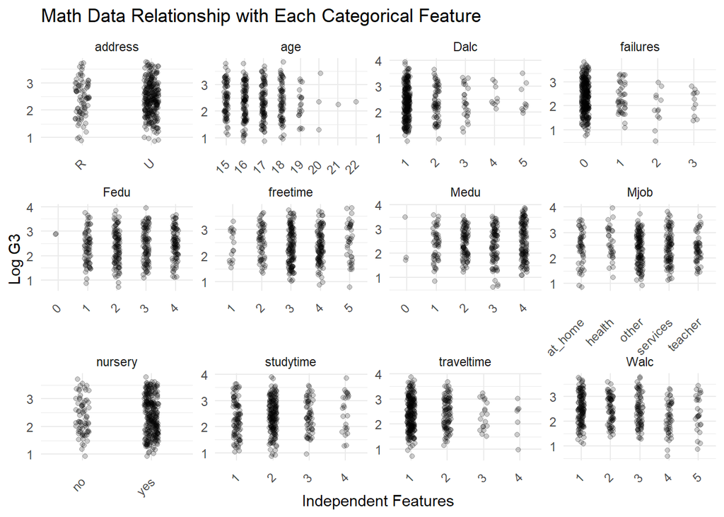

```r
selected.log.d1 <- log.d1 %>%
  dplyr::select(address, Medu, Mjob, traveltime, nursery, age, Dalc, failures, Fedu, freetime, Medu, studytime, traveltime, Walc, G3)

long.d1 <- selected.log.d1 %>% mutate(across(-G3, as.character))
long.d1 <- long.d1 %>%
  pivot_longer(cols = -G3)

long.d1 %>%
  ggplot(aes(x=value,y=G3))  + geom_jitter(width=0.1,height=1,alpha=0.2)+
  facet_wrap(~name,scales='free') +
  labs(x = "Independent Features", y = "Log G3", title = "Math Data Relationship with Each Categorical Feature")+
  theme_minimal() +
  theme(axis.text.x = element_text(angle = 45, vjust = 0.5, hjust=1))
```

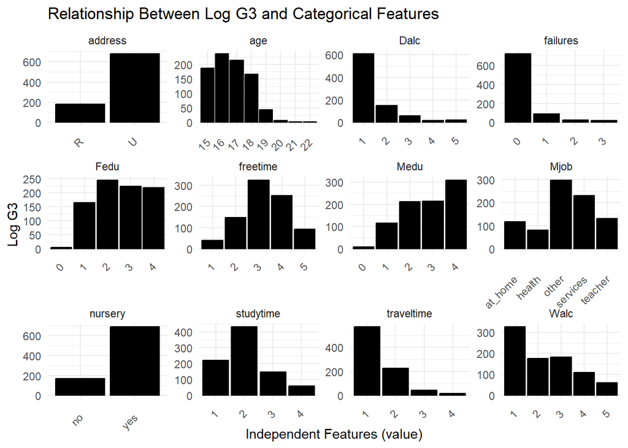

```r
long.d1 %>%
  ggplot(aes(x = value, y = G3)) +
  geom_col(fill = "skyblue", color = "black", alpha = 0.7) +
  facet_wrap(~name, scales = 'free') +
  labs(x = "Independent Features (value)", y = "Log G3", title = "Relationship Between Log G3 and Categorical Features") +
  theme_minimal() +
  theme(axis.text.x = element_text(angle = 45, vjust = 0.5, hjust = 1))
```

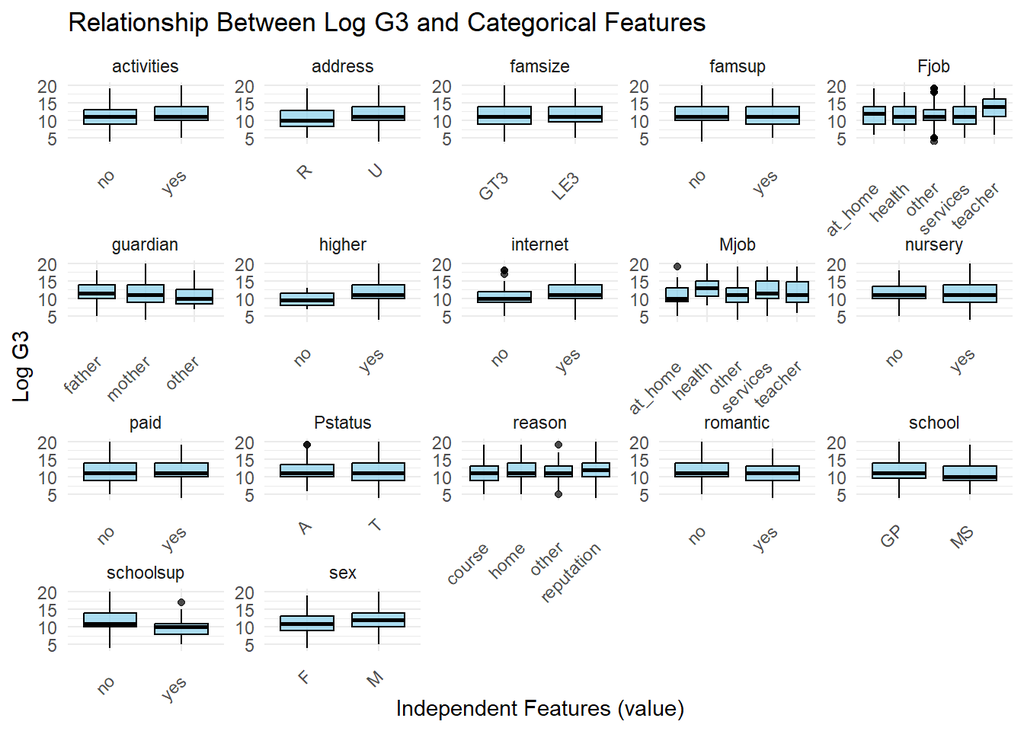

```r
selected.d1.categorical <- d1 %>%
  select_if(is.character)  %>%
  bind_cols(d1 %>% dplyr::select(G3))

selected.d1.categorical.long <- selected.d1.categorical %>% mutate(across(-G3))

selected.d1.categorical.long <- selected.d1.categorical.long %>%
  pivot_longer(cols = -G3)

selected.d1.categorical.long %>%
  ggplot(aes(x = value, y = G3)) +
  geom_boxplot(fill = "skyblue", color = "black", alpha = 0.7) +
  facet_wrap(~name, scales = 'free') +
  labs(x = "Independent Features (value)", y = "Log G3", title = "Relationship Between Log G3 and Categorical Features") +
  theme_minimal() +
  theme(axis.text.x = element_text(angle = 45, vjust = 0.5, hjust = 1))
```

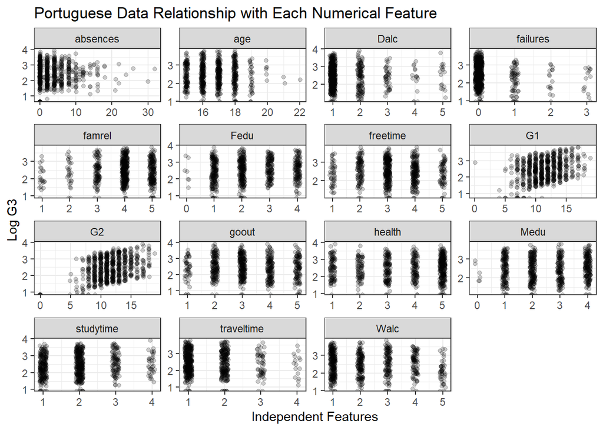

```r
log.d2 %>% dplyr::select(where(is.numeric)) %>% pivot_longer(-G3) %>%
  ggplot(aes(x=value,y=G3))+geom_jitter(width=0.1,height=1,alpha=0.2)+
  facet_wrap(~name,scales='free') +
  labs(x = "Independent Features", y = "Log G3", title = "Portuguese Data Relationship with Each Numerical Feature")
```

For Porturgese data set, we can see strong correlation between G1 and G3 and G2 and G3. There is also slight correlation between failures, absences, famrel, age, Dalc, Medu vs G3.

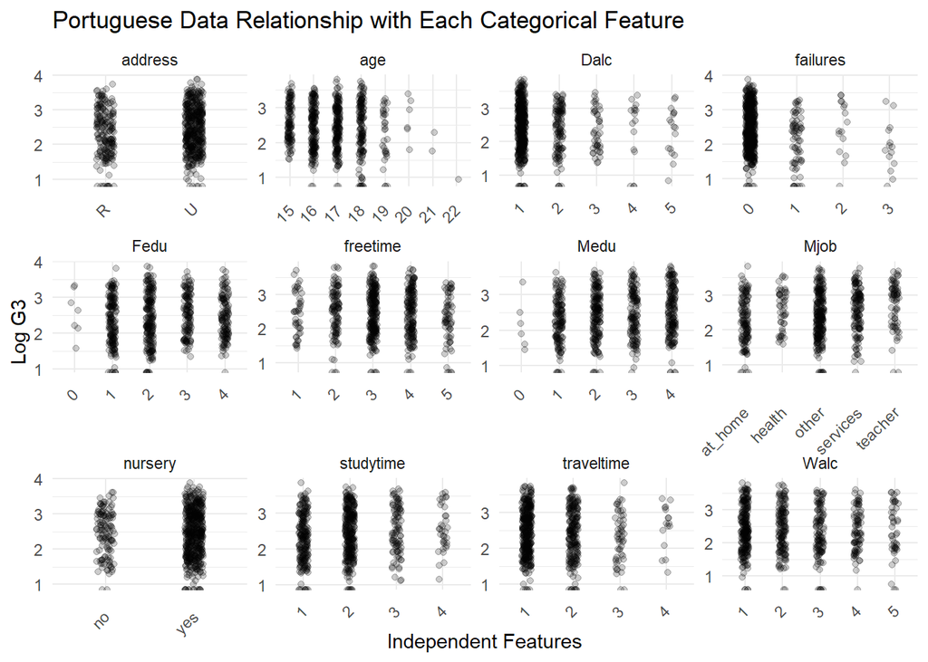

```r
selected.log.d2 <- log.d2 %>%
  dplyr::select(address, Medu, Mjob, traveltime, nursery, age, Dalc, failures, Fedu, freetime, Medu, studytime, traveltime, Walc, G3)

long.d2 <- selected.log.d2 %>% mutate(across(-G3, as.character))
long.d2 <- long.d2 %>%
  pivot_longer(cols = -G3)

long.d2 %>%
  ggplot(aes(x=value,y=G3))  + geom_jitter(width=0.1,height=1,alpha=0.2)+
  facet_wrap(~name,scales='free') +
  labs(x = "Independent Features", y = "Log G3", title = "Portuguese Data Relationship with Each Categorical Feature")+
  theme_minimal() +
  theme(axis.text.x = element_text(angle = 45, vjust = 0.5, hjust=1))
```

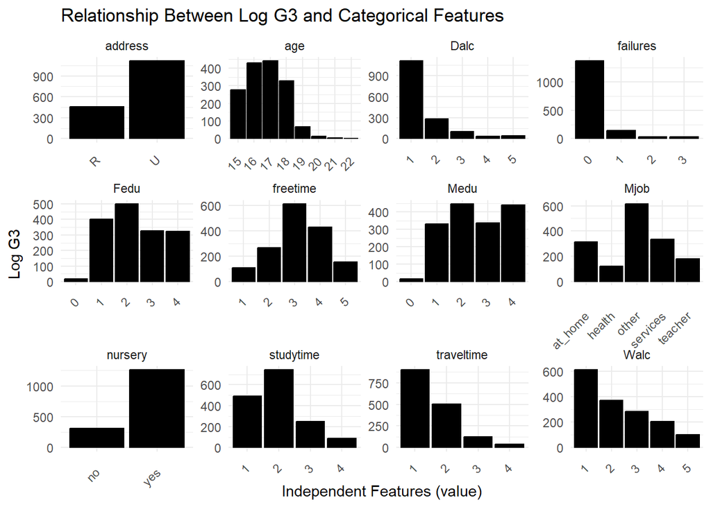

```r
long.d2 %>%
  ggplot(aes(x = value, y = G3)) +
  geom_col(fill = "skyblue", color = "black", alpha = 0.7) +
  facet_wrap(~name, scales = 'free') +
  labs(x = "Independent Features (value)", y = "Log G3", title = "Relationship Between Log G3 and Categorical Features") +
  theme_minimal() +
  theme(axis.text.x = element_text(angle = 45, vjust = 0.5, hjust = 1))
```

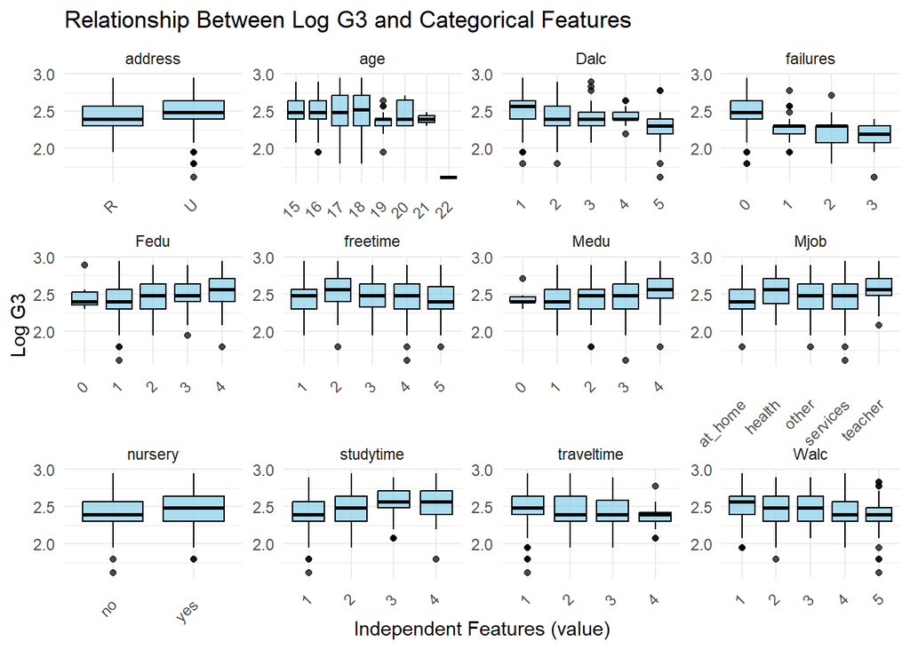

```r
long.d2 %>%
  ggplot(aes(x = value, y = G3)) +
  geom_boxplot(fill = "skyblue", color = "black", alpha = 0.7) +
  facet_wrap(~name, scales = 'free') +
  labs(x = "Independent Features (value)", y = "Log G3", title = "Relationship Between Log G3 and Categorical Features") +
  theme_minimal() +
  theme(axis.text.x = element_text(angle = 45, vjust = 0.5, hjust = 1))
```

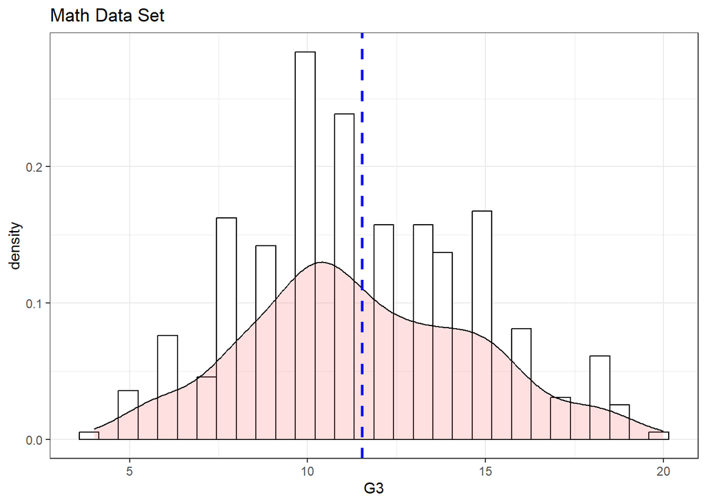

```r
p <- ggplot(d1, aes(x=G3)) +
  geom_histogram(aes(y=after_stat(density)), colour="black", fill="white")+
 geom_density(alpha=.2, fill="#FF6666")
# Add mean line
p+ geom_vline(aes(xintercept=mean(G3)),
            color="blue", linetype="dashed", size=1) + ggtitle(label = "Math Data Set")
```

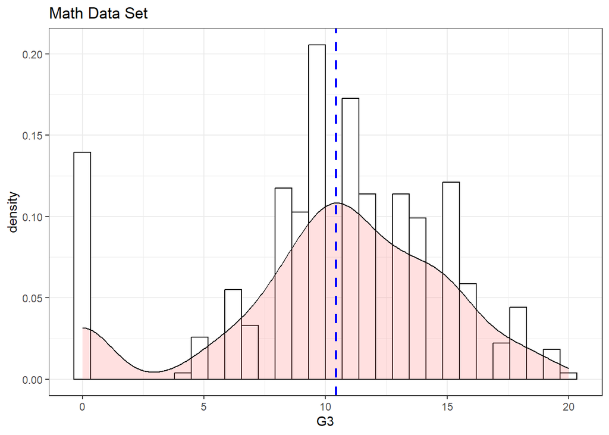

```r
p <- ggplot(og.d1, aes(x=G3)) +
  geom_histogram(aes(y=after_stat(density)), colour="black", fill="white")+
 geom_density(alpha=.2, fill="#FF6666")
# Add mean line
p+ geom_vline(aes(xintercept=mean(G3)),
            color="blue", linetype="dashed", size=1) + ggtitle(label = "Math Data Set")
```

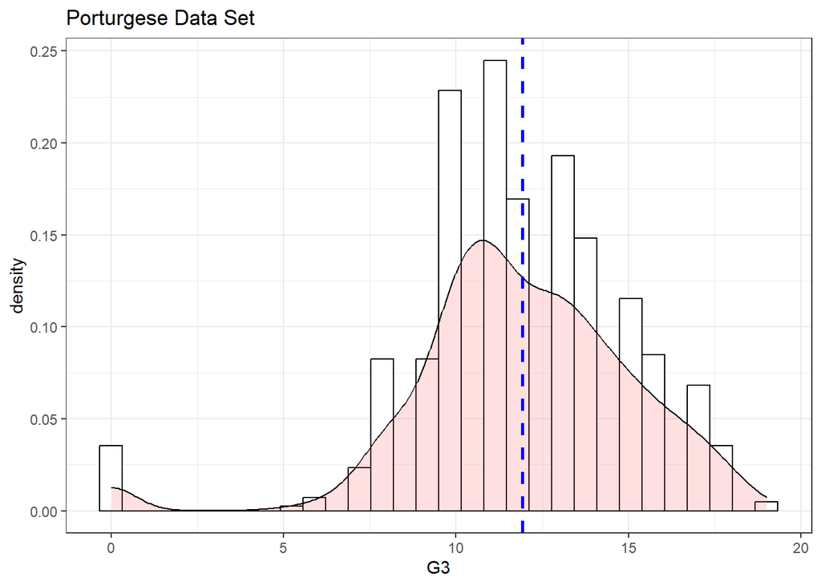

```r
p <- ggplot(d2, aes(x=G3)) +
  geom_histogram(aes(y=after_stat(density)), colour="black", fill="white")+
 geom_density(alpha=.2, fill="#FF6666")
# Add mean line
p+ geom_vline(aes(xintercept=mean(G3)),
            color="blue", linetype="dashed", size=1) + ggtitle(label = "Porturgese Data Set")
```

# ——————————

# Part 1: Portuguese Dataset (Including G1 and G2)

# ——————————

Model Selection Code is written by Yizhen Pan.

```r
# Load the dataset and filter out rows with G3 = 0
port_data <- read.csv("student/student-por.csv", sep = ";") %>%
  filter(G3 != 0)
# Convert character columns to factors
factor_cols <- sapply(port_data, is.character)
port_data[factor_cols] <- lapply(port_data[factor_cols], factor)
# Identify Outliers in G3
port_data$G3_zscore <- scale(port_data$G3)
port_data <- port_data[abs(port_data$G3_zscore) <= 3, ]
port_data <- port_data %>% dplyr::select(-G3_zscore)
# Train-test split (70% training, 30% testing)
set.seed(42)
train_index <- sample(1:nrow(port_data), size = floor(0.7 * nrow(port_data)))
train_port <- port_data[train_index, ]
test_port <- port_data[-train_index, ]
# --- RMSE Calculation Function ---
calculate_rmse <- function(true_values, predicted_values) {
  sqrt(mean((true_values - predicted_values)^2))
}
# --- R² and Adjusted R² Calculation Functions ---
calculate_r2 <- function(true_values, predicted_values) {
  ss_total <- sum((true_values - mean(true_values))^2)
  ss_residual <- sum((true_values - predicted_values)^2)
  1 - (ss_residual / ss_total)
}
calculate_adj_r2 <- function(r2, n, k) {
  1 - (1 - r2) * ((n - 1) / (n - k - 1))
}
# --- Model Fitting ---
# 1. Initial Linear Model
lin_mod_port <- lm(G3 ~ ., data = train_port)
# Extract the summary to get p-values
lin_mod_summary <- summary(lin_mod_port)
p_values <- coef(lin_mod_summary)[, "Pr(>|t|)"]
# Identify significant predictors (p-value < 0.1), excluding the intercept
significant_terms <- names(p_values)[p_values < 0.1 & names(p_values) != "(Intercept)"]
# Map the significant terms back to the original variable names
# Get the model matrix and assign attribute
mm <- model.matrix(lin_mod_port)
assign <- attr(mm, "assign")
# Get the terms labels
terms_obj <- terms(lin_mod_port)
terms_labels <- attr(terms_obj, "term.labels")
# Map each coefficient to the corresponding variable
coef_names <- names(coef(lin_mod_port))
coef_terms <- sapply(assign, function(x) if (x == 0) "(Intercept)" else terms_labels[x])
# Create a data frame mapping coefficients to variables
coef_variable_map <- data.frame(
  term = coef_names,
  variable = coef_terms,
  stringsAsFactors = FALSE
)
# Get unique variable names corresponding to significant terms
significant_variables <- unique(coef_variable_map$variable[coef_variable_map$term %in% significant_terms])
# Create formula with significant variables
significant_formula <- as.formula(paste("G3 ~", paste(significant_variables, collapse = " + ")))
# Refit the refined Linear Model
refined_lin_mod_port <- lm(significant_formula, data = train_port)
# 2. Repeat the same process for the Log-Transformed Model
log_mod_port <- lm(log(G3) ~ ., data = train_port)
log_mod_summary <- summary(log_mod_port)
p_values_log <- coef(log_mod_summary)[, "Pr(>|t|)"]
significant_terms_log <- names(p_values_log)[p_values_log < 0.1 & names(p_values_log) != "(Intercept)"]
# Map the significant terms back to variables
mm_log <- model.matrix(log_mod_port)
assign_log <- attr(mm_log, "assign")
terms_obj_log <- terms(log_mod_port)
terms_labels_log <- attr(terms_obj_log, "term.labels")
coef_names_log <- names(coef(log_mod_port))
coef_terms_log <- sapply(assign_log, function(x) if (x == 0) "(Intercept)" else terms_labels_log[x])
coef_variable_map_log <- data.frame(
  term = coef_names_log,
  variable = coef_terms_log,
  stringsAsFactors = FALSE
)
significant_variables_log <- unique(coef_variable_map_log$variable[coef_variable_map_log$term %in% significant_terms_log])
significant_formula_log <- as.formula(paste("log(G3) ~", paste(significant_variables_log, collapse = " + ")))
# Refit the refined Log-Transformed Model
refined_log_mod_port <- lm(significant_formula_log, data = train_port)
# 3. Backward Selection Model
backward_mod_port <- stepAIC(lin_mod_port, direction = "backward", trace = FALSE)
# 4. Stepwise Selection Model
stepwise_mod_port <- stepAIC(lin_mod_port, direction = "both", trace = FALSE)
# --- Performance Metrics Calculation ---
models_port <- list(
  "Refined Linear Model" = refined_lin_mod_port,
  "Refined Log-Transformed Model" = refined_log_mod_port,
  "Backward Model" = backward_mod_port,
  "Stepwise Model" = stepwise_mod_port
)
results_port <- data.frame()
for (model_name in names(models_port)) {
  model <- models_port[[model_name]]

  # Number of predictors
  n_train <- nrow(train_port)
  k <- length(coef(model)) - 1  # Subtract 1 for the intercept

  # In-Sample Predictions
  if (grepl("log\\(G3\\)", as.character(model$call$formula)[2])) {
    # For log-transformed model, exponentiate predictions
    train_predictions <- exp(predict(model, train_port))
    test_predictions <- exp(predict(model, test_port))
  } else {
    train_predictions <- predict(model, train_port)
    test_predictions <- predict(model, test_port)
  }

  # In-Sample RMSE Calculation (Step by Step)
  residuals_train <- train_port$G3 - train_predictions
  squared_residuals_train <- residuals_train^2
  mse_train <- mean(squared_residuals_train)
  rmse_train <- sqrt(mse_train)

  # Out-of-Sample RMSE Calculation (Step by Step)
  residuals_test <- test_port$G3 - test_predictions
  squared_residuals_test <- residuals_test^2
  mse_test <- mean(squared_residuals_test)
  rmse_test <- sqrt(mse_test)

  # R² and Adjusted R²
  r2_train <- calculate_r2(train_port$G3, train_predictions)
  adj_r2_train <- calculate_adj_r2(r2_train, n_train, k)

  r2_test <- calculate_r2(test_port$G3, test_predictions)

  # Compile Results
  results_port <- rbind(results_port, data.frame(
    Model = model_name,
    RMSE_Train = rmse_train,
    R2_Train = r2_train,
    Adj_R2_Train = adj_r2_train,
    RMSE_Test = rmse_test,
    R2_Test = r2_test
  ))
}
# Display the results
cat("\nPortuguese Dataset Model Performance:\n")
```

```
##
## Portuguese Dataset Model Performance:
```

```r
print(results_port)
```

```
##                           Model RMSE_Train    R2_Train Adj_R2_Train  RMSE_Test
## 1          Refined Linear Model  0.8362972   0.9013628    0.8988454  0.8323764
## 2 Refined Log-Transformed Model 10.0313950 -13.1919447  -13.5879990 10.0433795
## 3                Backward Model  0.8208204   0.9049799    0.9016420  0.8492676
## 4                Stepwise Model  0.8208204   0.9049799    0.9016420  0.8492676
##       R2_Test
## 1   0.9002831
## 2 -13.5174121
## 3   0.8961949
## 4   0.8961949
```

# — Identify the Most Appropriate Model —

Based on RMSE and R² values, the backward model is most appropriate for the portguese set Reason: 1.Superior Performance: Slightly better RMSE and R² values compared to the Refined Linear Model (0.8208 vs 0.8362 in RMSE train, 0.9049 vs 0.9013 in R^2 train). 2.Generalization: Similar performance metrics on training and testing sets suggest the model generalizes well to unseen data.

```r
# Function to extract significant standardized coefficients
extract_significant_coefs <- function(model, model_name, p_threshold = 0.1) {
  # Calculate standardized coefficients
  standardized_model <- lm.beta::lm.beta(model)

  # Tidy the model output
  tidy_model <- broom::tidy(standardized_model)

  # Rename the estimate column to standardized_estimate
  tidy_model <- tidy_model %>%
    rename(standardized_estimate = estimate)

  # Add the model name
  tidy_model <- tidy_model %>%
    mutate(model = model_name)

  # Filter out the intercept and non-significant predictors
  significant_coefs <- tidy_model %>%
    filter(term != "(Intercept)" & p.value < p_threshold)

  return(significant_coefs)
}
# Extract significant coefficients from the Backward Selection Model
significant_coefficients_port <- extract_significant_coefs(backward_mod_port, "Backward Selection Model", p_threshold = 0.1)
# Inspect the significant coefficients
print("Significant Standardized Coefficients (p < 0.1) in Backward Selection Model:")
```

```
## [1] "Significant Standardized Coefficients (p < 0.1) in Backward Selection Model:"
```

```r
print(significant_coefficients_port)
```

```
## # A tibble: 13 × 7
##    term    standardized_estimate std_estimate std.error statistic  p.value model
##    <chr>                   <dbl>        <dbl>     <dbl>     <dbl>    <dbl> <chr>
##  1 school…               -0.163       -0.0288   0.0952      -1.71 8.78e- 2 Back…
##  2 sexM                  -0.238       -0.0434   0.0848      -2.81 5.25e- 3 Back…
##  3 age                    0.0872       0.0393   0.0369       2.36 1.87e- 2 Back…
##  4 Medu                   0.113        0.0480   0.0414       2.73 6.50e- 3 Back…
##  5 Fjobhe…               -0.725       -0.0492   0.271       -2.67 7.78e- 3 Back…
##  6 Fjobot…               -0.411       -0.0767   0.163       -2.52 1.21e- 2 Back…
##  7 Fjobse…               -0.333       -0.0558   0.171       -1.95 5.19e- 2 Back…
##  8 Fjobte…               -0.429       -0.0392   0.231       -1.85 6.44e- 2 Back…
##  9 travel…                0.156        0.0446   0.0559       2.80 5.39e- 3 Back…
## 10 failur…               -0.180       -0.0402   0.0771      -2.34 1.97e- 2 Back…
## 11 absenc…               -0.0152      -0.0277   0.00874     -1.74 8.33e- 2 Back…
## 12 G1                     0.175        0.178    0.0315       5.56 4.71e- 8 Back…
## 13 G2                     0.764        0.749    0.0328      23.3  4.03e-78 Back…
```

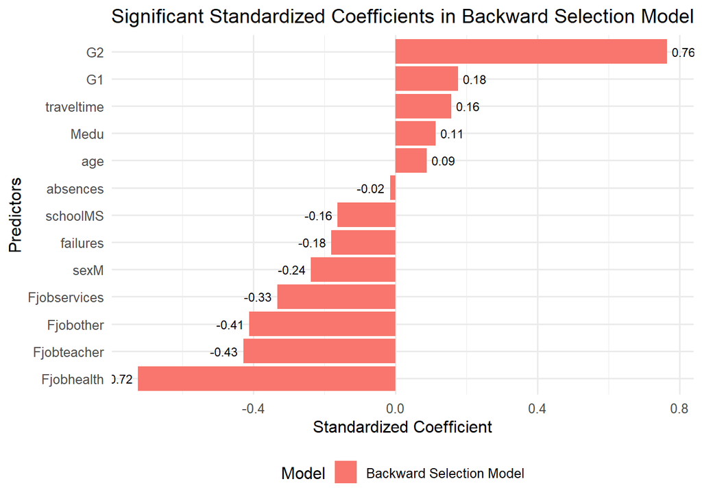

```r
# Check if there are any significant coefficients to plot
if(nrow(significant_coefficients_port) > 0) {

  # Create the bar plot
  ggplot(significant_coefficients_port, aes(x = reorder(term, standardized_estimate),
                                           y = standardized_estimate,
                                           fill = model)) +
    geom_bar(stat = "identity", position = position_dodge(width = 0.8)) +
    geom_text(aes(label = round(standardized_estimate, 2)),
              position = position_dodge(width = 0.8),
              hjust = ifelse(significant_coefficients_port$standardized_estimate > 0, -0.2, 1.2),
              size = 3) +
    coord_flip() +
    labs(
      title = "Significant Standardized Coefficients in Backward Selection Model",
      x = "Predictors",
      y = "Standardized Coefficient",
      fill = "Model"
    ) +
    theme_minimal(base_size = 12) +
    theme(
      legend.position = "bottom",
      plot.title = element_text(hjust = 0.5)
    )

} else {
  cat("No significant coefficients (p < 0.1) found in the Backward Selection Model.\n")
}
```

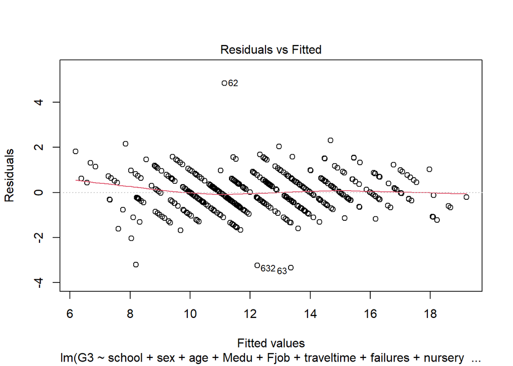

```r
# Residuals vs Fitted Values
plot(backward_mod_port, which = 1)
```

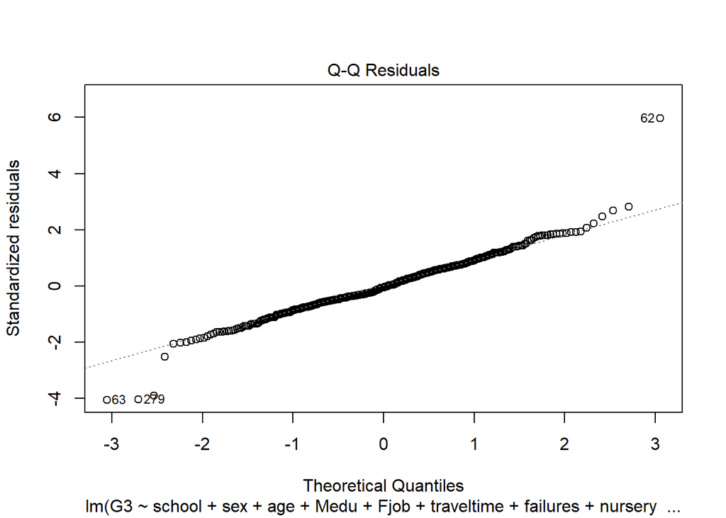

```r
# Q-Q Plot for Residuals
plot(backward_mod_port, which = 2)
```

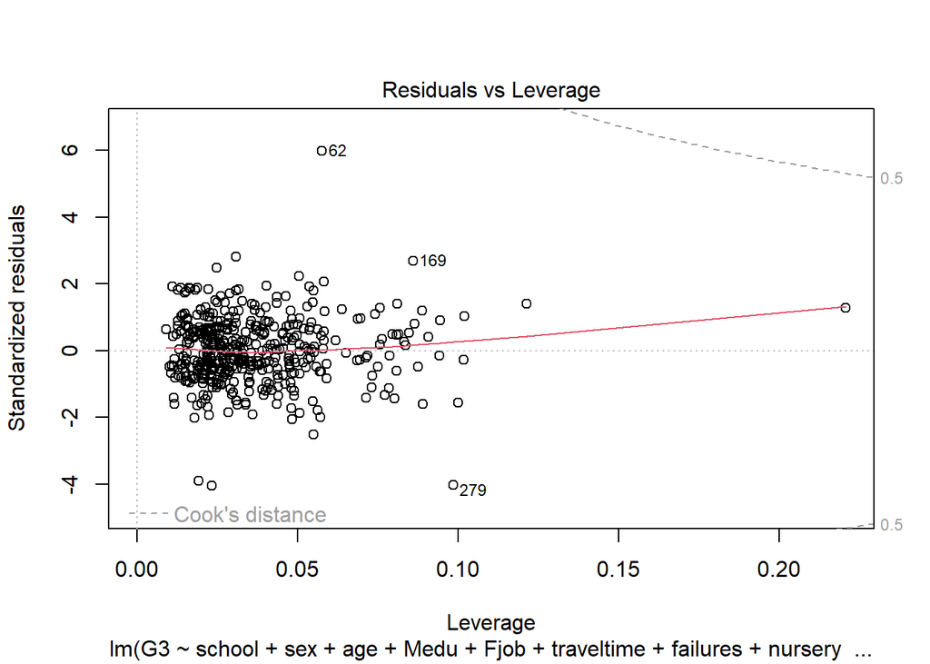

```r
plot(backward_mod_port, which = 5)
```

```r
# Multicollinearity Assessment
vif_values_backward <- car::vif(backward_mod_port)
# Display VIF results
print("VIF Values for Backward Selection Model:")
```

```
## [1] "VIF Values for Backward Selection Model:"
```

```r
print(vif_values_backward)
```

```
##                GVIF Df GVIF^(1/(2*Df))
## school     1.272898  1        1.128228
## sex        1.076604  1        1.037595
## age        1.245381  1        1.115966
## Medu       1.382020  1        1.175593
## Fjob       1.261489  4        1.029462
## traveltime 1.143637  1        1.069410
## failures   1.323161  1        1.150287
## nursery    1.052458  1        1.025894
## higher     1.247442  1        1.116890
## absences   1.143655  1        1.069418
## G1         4.621336  1        2.149729
## G2         4.641203  1        2.154345
```

# ——————————

# Part 2: Math Dataset (Including G1 and G2)

# ——————————

```r
# ------------------------------
# Part 1: Data Preparation
# ------------------------------
# Load the dataset and filter out rows with G3 = 0
math_data <- read.csv("student/student-mat.csv", sep = ";") %>%
  filter(G3 != 0)
# Convert character columns to factors
factor_cols <- sapply(math_data, is.character)
math_data[factor_cols] <- lapply(math_data[factor_cols], factor)
# Note: Outliers are retained as per the current requirement
# Train-test split (70% training, 30% testing)
set.seed(42)
train_index <- sample(1:nrow(math_data), size = floor(0.7 * nrow(math_data)))
train_math <- math_data[train_index, ]
test_math <- math_data[-train_index, ]
# ------------------------------
# Part 2: Model Fitting
# ------------------------------
# Initial Linear Model for Math Dataset
lin_mod_math <- lm(G3 ~ ., data = train_math)
lin_mod_summary_math <- summary(lin_mod_math)
p_values_math <- coef(lin_mod_summary_math)[, "Pr(>|t|)"]
significant_terms_math <- names(p_values_math)[p_values_math < 0.1 & names(p_values_math) != "(Intercept)"]

# Map significant terms back to original variables
mm_math <- model.matrix(lin_mod_math)
assign_math <- attr(mm_math, "assign")
terms_obj_math <- terms(lin_mod_math)
terms_labels_math <- attr(terms_obj_math, "term.labels")
coef_names_math <- names(coef(lin_mod_math))
coef_terms_math <- sapply(assign_math, function(x) if (x == 0) "(Intercept)" else terms_labels_math[x])
coef_variable_map_math <- data.frame(
  term = coef_names_math,
  variable = coef_terms_math,
  stringsAsFactors = FALSE
)
significant_variables_math <- unique(coef_variable_map_math$variable[coef_variable_map_math$term %in% significant_terms_math])
significant_formula_math <- as.formula(paste("G3 ~", paste(significant_variables_math, collapse = " + ")))
refined_lin_mod_math <- lm(significant_formula_math, data = train_math)

# Repeat for Log-Transformed Model
log_mod_math <- lm(log(G3) ~ ., data = train_math)
log_mod_summary_math <- summary(log_mod_math)
p_values_log_math <- coef(log_mod_summary_math)[, "Pr(>|t|)"]
significant_terms_log_math <- names(p_values_log_math)[p_values_log_math < 0.1 & names(p_values_log_math) != "(Intercept)"]

mm_log_math <- model.matrix(log_mod_math)
assign_log_math <- attr(mm_log_math, "assign")
terms_obj_log_math <- terms(log_mod_math)
terms_labels_log_math <- attr(terms_obj_log_math, "term.labels")
coef_names_log_math <- names(coef(log_mod_math))
coef_terms_log_math <- sapply(assign_log_math, function(x) if (x == 0) "(Intercept)" else terms_labels_log_math[x])
coef_variable_map_log_math <- data.frame(
  term = coef_names_log_math,
  variable = coef_terms_log_math,
  stringsAsFactors = FALSE
)
significant_variables_log_math <- unique(coef_variable_map_log_math$variable[coef_variable_map_log_math$term %in% significant_terms_log_math])
significant_formula_log_math <- as.formula(paste("log(G3) ~", paste(significant_variables_log_math, collapse = " + ")))
refined_log_mod_math <- lm(significant_formula_log_math, data = train_math)
backward_mod_math <- stepAIC(lin_mod_math, direction = "backward", trace = FALSE)
stepwise_mod_math <- stepAIC(lin_mod_math, direction = "both", trace = FALSE)
# Add refined models to the list of models for evaluation
models_math <- list(
  "Refined Linear Model" = refined_lin_mod_math,
  "Refined Log-Transformed Model" = refined_log_mod_math,
  "Backward Model" = backward_mod_math,
  "Stepwise Model" = stepwise_mod_math
)

# Initialize results data frame
results_math <- data.frame()
# Evaluate each model
for (model_name in names(models_math)) {
  model <- models_math[[model_name]]

  # Number of predictors
  k <- length(coef(model)) - 1

  # Predictions
  if (model_name == "Log-Transformed Model") {
    train_predictions <- exp(predict(model, train_math))
    test_predictions <- exp(predict(model, test_math))
  } else {
    train_predictions <- predict(model, train_math)
    test_predictions <- predict(model, test_math)
  }

  # RMSE
  rmse_train <- calculate_rmse(train_math$G3, train_predictions)
  rmse_test <- calculate_rmse(test_math$G3, test_predictions)

  # R²
  r2_train <- calculate_r2(train_math$G3, train_predictions)
  r2_test <- calculate_r2(test_math$G3, test_predictions)

  # Adjusted R²
  adj_r2_train <- calculate_adj_r2(r2_train, nrow(train_math), k)
  adj_r2_test <- calculate_adj_r2(r2_test, nrow(test_math), k)

  # Compile results
  results_math <- bind_rows(results_math, data.frame(
    Model = model_name,
    Dataset = "Math",
    RMSE_Train = round(rmse_train, 4),
    R2_Train = round(r2_train, 4),
    Adj_R2_Train = round(adj_r2_train, 4),
    Adj_R2_Test = round(adj_r2_test, 4),
    RMSE_Test = round(rmse_test, 4),
    R2_Test = round(r2_test, 4)
  ))
}
# Display model performance
cat("\nMath Dataset Model Performance:\n")
```

```
##
## Math Dataset Model Performance:
```

```r
print(results_math)
```

```
##                           Model Dataset RMSE_Train R2_Train Adj_R2_Train
## 1          Refined Linear Model    Math     0.7847   0.9381       0.9368
## 2 Refined Log-Transformed Model    Math     9.8094  -8.6716      -9.2066
## 3                Backward Model    Math     0.7814   0.9386       0.9374
## 4                Stepwise Model    Math     0.7774   0.9393       0.9377
##   Adj_R2_Test RMSE_Test R2_Test
## 1      0.9282    0.8604  0.9315
## 2     -7.6057    9.0400 -6.5602
## 3      0.9283    0.8595  0.9317
## 4      0.9289    0.8520  0.9328
```

# Choose Stepwise model

The stepwise model has the lowest RMSE in train (0.7774) and test (0.8520), high R^2 value of (0.9393 in train and 0.9328 in test) and high adjusted R^2 values The stepwise itself also auto select the most significant predictors.

```r
# ------------------------------
# Part 4: Extracting and Visualizing Significant Coefficients (p < 0.1)
# ------------------------------
# Function to extract significant standardized coefficients
extract_significant_coefs <- function(model, model_name, p_threshold = 0.1) {
  # Calculate standardized coefficients
  standardized_model <- lm.beta::lm.beta(model)

  # Tidy the model output
  tidy_model <- broom::tidy(standardized_model)

  # Rename the estimate column to standardized_estimate
  tidy_model <- tidy_model %>%
    rename(standardized_estimate = estimate)

  # Add the model name
  tidy_model <- tidy_model %>%
    mutate(model = model_name)

  # Filter out the intercept and non-significant predictors
  significant_coefs <- tidy_model %>%
    filter(term != "(Intercept)" & p.value < p_threshold)

  return(significant_coefs)
}
# Extract significant coefficients from the Stepwise Selection Model
significant_coefficients_math <- extract_significant_coefs(stepwise_mod_math, "Stepwise Selection Model", p_threshold = 0.1)
# Inspect the significant coefficients
print("Significant Standardized Coefficients (p < 0.1) in Stepwise Selection Model:")
```

```
## [1] "Significant Standardized Coefficients (p < 0.1) in Stepwise Selection Model:"
```

```r
print(significant_coefficients_math)
```

```
## # A tibble: 4 × 7
##   term   standardized_estimate std_estimate std.error statistic  p.value model
##   <chr>                  <dbl>        <dbl>     <dbl>     <dbl>    <dbl> <chr>
## 1 famrel                0.138        0.0374    0.0585      2.35 1.94e- 2 Stepwi…
## 2 health               -0.0609      -0.0272    0.0357     -1.71 8.88e- 2 Stepwi…
## 3 G1                    0.100        0.105     0.0350      2.86 4.57e- 3 Stepwi…
## 4 G2                    0.876        0.865     0.0374     23.4  4.17e-64 Stepwi…
```

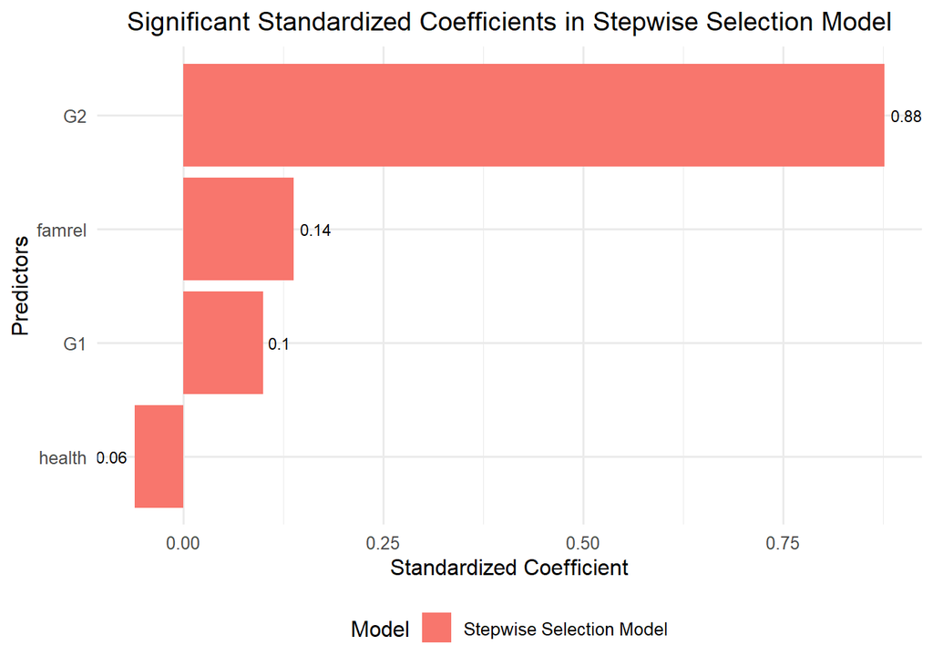

```r
# Check if there are any significant coefficients to plot
if(nrow(significant_coefficients_math) > 0) {

  # Create the bar plot
  ggplot(significant_coefficients_math, aes(x = reorder(term, standardized_estimate),
                                           y = standardized_estimate,
                                           fill = model)) +
    geom_bar(stat = "identity", position = position_dodge(width = 0.8)) +
    geom_text(aes(label = round(standardized_estimate, 2)),
              position = position_dodge(width = 0.8),
              hjust = ifelse(significant_coefficients_math$standardized_estimate > 0, -0.2, 1.2),
              size = 3) +
    coord_flip() +
    labs(
      title = "Significant Standardized Coefficients in Stepwise Selection Model",
      x = "Predictors",
      y = "Standardized Coefficient",
      fill = "Model"
    ) +
    theme_minimal(base_size = 12) +
    theme(
      legend.position = "bottom",
      plot.title = element_text(hjust = 0.5)
    )

} else {
  cat("No significant coefficients (p < 0.1) found in the Stepwise Selection Model.\n")
}
```

```r
# Calculate VIF for the Stepwise Selection Model
vif_values_stepwise <- car::vif(stepwise_mod_math)
# Display VIF results
print("VIF Values for Stepwise Selection Model:")
```

```
## [1] "VIF Values for Stepwise Selection Model:"
```

```r
print(vif_values_stepwise)
```

```
##   famrel   health absences       G1       G2    goout
## 1.007142 1.012235 1.055771 5.359774 5.443662 1.015130
```

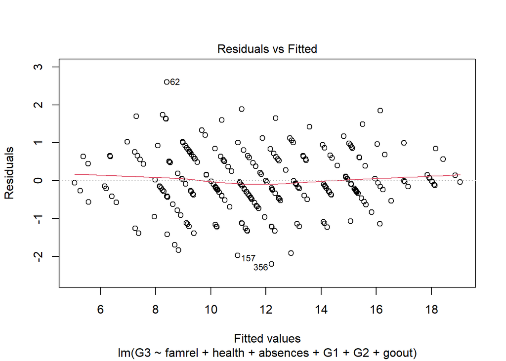

```r
# Residuals vs Fitted Values
plot(stepwise_mod_math, which = 1)
```

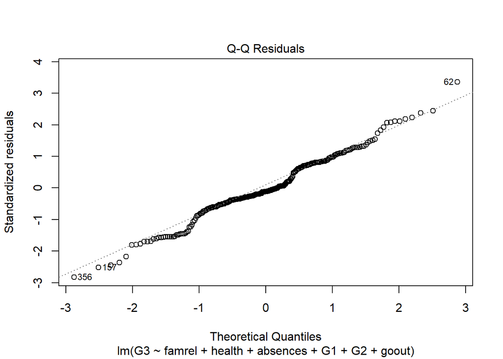

```r
# Q-Q Plot for Residuals
plot(stepwise_mod_math, which = 2)
```

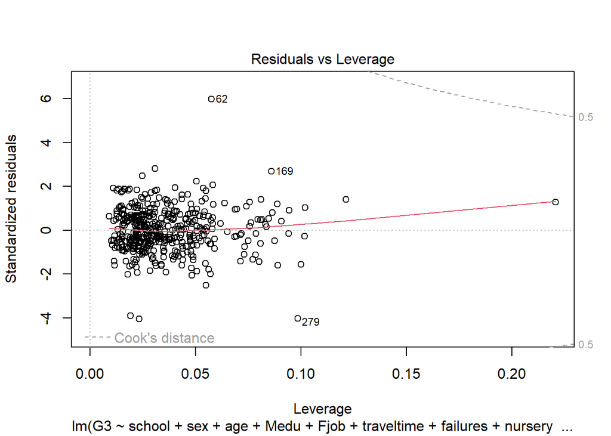

```r
plot(stepwise_mod_port, which = 5)
```

## Assumption checking

Assumption Code is written by Zichun Han.

1. Linearity Assumption
   - Visual Inspection: The residuals vs. fitted values plots show if there’s a clear pattern, which might indicate non-linearity. Ideally, residuals should be randomly scattered around zero.
   - Math vs. Portuguese Data: Both datasets’ scatter plots with linear regression lines indicate relationships between `G3` and each predictor variable, showing if linearity holds for each independent variable.
   - Interpretation: In your residual plots, if the red line (smoother) remains close to zero without any distinct pattern, the linearity assumption is reasonably met.
2. Homoscedasticity Assumption
- Visual Inspection: Homoscedasticity means that the variance of residuals is constant across fitted values. In your residual vs. fitted values plots, check for a funnel or fan shape which would indicate heteroscedasticity.
- Interpretation: If residuals spread evenly above and below the zero line, homoscedasticity is likely satisfied. However, if the residuals show increasing or decreasing variance as fitted values increase, heteroscedasticity may be present.
3. Normality of Residuals
- Q-Q Plots: Q-Q plots for both models show if residuals follow a normal distribution. Residuals should fall along the 45-degree reference line for normality.
- Interpretation: Deviations from the line, particularly at the ends (tails), suggest that residuals may not be normally distributed. Small deviations are often acceptable, but larger deviations (such as heavy tails) may affect model assumptions.
4. Independence of Residuals
- Visual Patterns: Independence of residuals implies that residuals are not correlated with each other. This is harder to check visually, but in time-series or spatial data, patterns or clusters in residuals could indicate dependency.
- Interpretation: Since there’s no evident time or spatial ordering here, independence is usually assumed unless known violations are present in data collection methods.

Conclusion: - Model Fit Adequacy: If all assumptions are reasonably met, your model fit is considered reliable for inference.

### Linear

[figure not shown]

```r
port_data %>%
  dplyr::select(G2, G1, traveltime, Medu, age, absences, failures, G3) %>%
  pivot_longer(-G3) %>%
  ggplot(aes(x = value, y = G3)) +
  geom_jitter(width = 0.1, height = 1, alpha = 0.2) +
  geom_smooth(method = "lm", color = "red", se = FALSE) +
  facet_wrap(~name, scales = 'free') +
  labs(x = "Independent Features", y = "G3", title = "Math Data Relationship with Each Numerical Feature")
```

[figure not shown]

```r
math_data %>%
  dplyr::select(G2, famrel, G1, failures, health, G3) %>%
  pivot_longer(-G3) %>%
  ggplot(aes(x = value, y = G3)) +
  geom_jitter(width = 0.1, height = 1, alpha = 0.2) +
  geom_smooth(method = "lm", color = "red", se = FALSE) +
  facet_wrap(~name, scales = 'free') +
  labs(x = "Independent Features", y = "G3", title = "Portuguese Data Relationship with Each Numerical Feature")
```